# 01_intervals_inc_dec_pos_neg_quad

## 01_intervals_inc_dec_pos_neg_quad

#### Question

1. Consider the quadratic function graphed below:

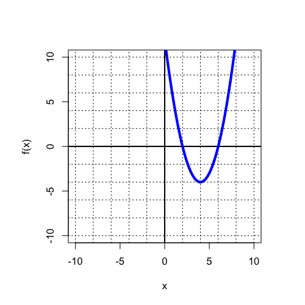

   - What is the interval(s) over which the function is positive?
   - What is the interval(s) over which the function is negative?
   - What is the interval(s) over which the function is increasing?
   - What is the interval(s) over which the function is decreasing?
   - What is the domain (in interval notation)?
   - What is the range (in interval notation)?

#### Question

2. Consider the quadratic function graphed below:

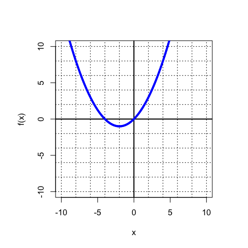

   - What is the interval(s) over which the function is positive?
   - What is the interval(s) over which the function is negative?
   - What is the interval(s) over which the function is increasing?
   - What is the interval(s) over which the function is decreasing?
   - What is the domain (in interval notation)?
   - What is the range (in interval notation)?

#### Question

3. Consider the quadratic function graphed below:

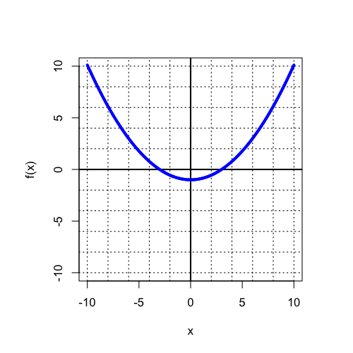

   - What is the interval(s) over which the function is positive?
   - What is the interval(s) over which the function is negative?
   - What is the interval(s) over which the function is increasing?
   - What is the interval(s) over which the function is decreasing?
   - What is the domain (in interval notation)?
   - What is the range (in interval notation)?

#### Question

4. Consider the quadratic function graphed below:

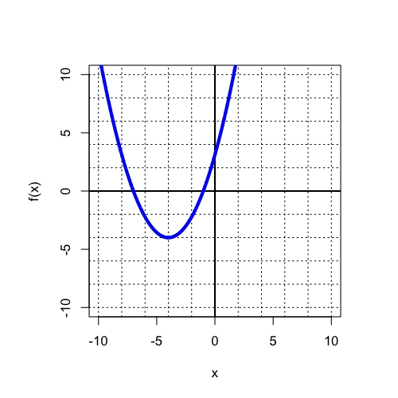

   - What is the interval(s) over which the function is positive?
   - What is the interval(s) over which the function is negative?
   - What is the interval(s) over which the function is increasing?
   - What is the interval(s) over which the function is decreasing?
   - What is the domain (in interval notation)?
   - What is the range (in interval notation)?

#### Question

5. Consider the quadratic function graphed below:

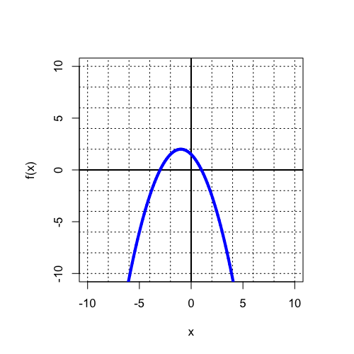

   - What is the interval(s) over which the function is positive?
   - What is the interval(s) over which the function is negative?
   - What is the interval(s) over which the function is increasing?
   - What is the interval(s) over which the function is decreasing?
   - What is the domain (in interval notation)?
   - What is the range (in interval notation)?

#### Question

6. Consider the quadratic function graphed below:

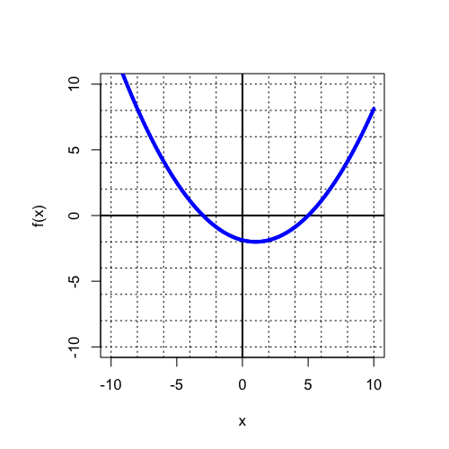

   - What is the interval(s) over which the function is positive?
   - What is the interval(s) over which the function is negative?
   - What is the interval(s) over which the function is increasing?
   - What is the interval(s) over which the function is decreasing?
   - What is the domain (in interval notation)?
   - What is the range (in interval notation)?

#### Question

7. Consider the quadratic function graphed below:

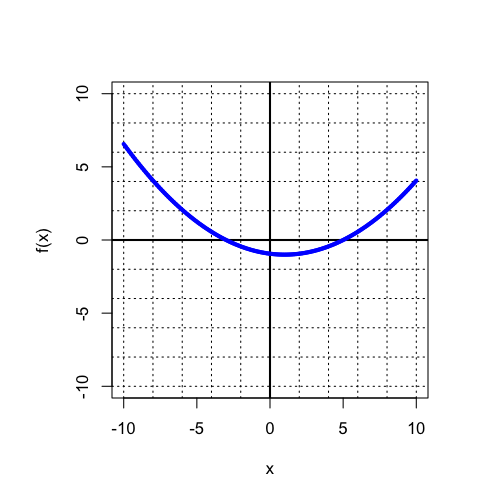

   - What is the interval(s) over which the function is positive?
   - What is the interval(s) over which the function is negative?
   - What is the interval(s) over which the function is increasing?
   - What is the interval(s) over which the function is decreasing?
   - What is the domain (in interval notation)?
   - What is the range (in interval notation)?

#### Question

8. Consider the quadratic function graphed below:

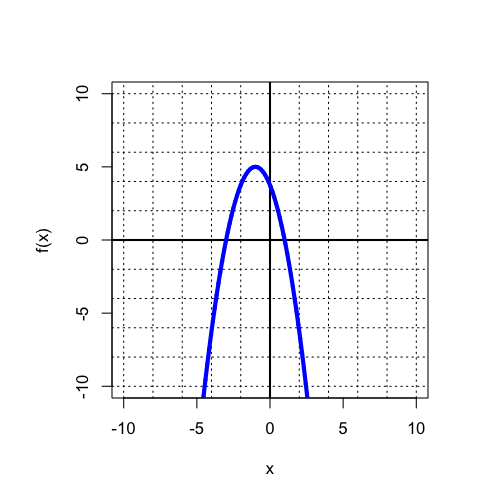

   - What is the interval(s) over which the function is positive?
   - What is the interval(s) over which the function is negative?
   - What is the interval(s) over which the function is increasing?
   - What is the interval(s) over which the function is decreasing?
   - What is the domain (in interval notation)?
   - What is the range (in interval notation)?